# Practical 5: Measures of Association

Dr Jennifer Mankin

10/01/2020

# Study 1: Do Children Imitate Robots?

## Task 1: Import Data

First, save the data file from [Week 6 on Canvas](https://canvas.sussex.ac.uk/courses/9242/pages/week-6), `imitation.csv`, to the `data` folder on your N: drive. Then, run the following code to import and get a look at the data.

```r
nao <- read_csv("../data/imitation.csv")
nao
```

```
## # A tibble: 270 x 5
##       id condition   sex phase oi.score
##    <dbl>     <dbl> <dbl> <dbl>    <dbl>
##  1     1         0     0     1        0
##  2     1         0     0     2        0
##  3     1         0     0     3        0
##  4     2         0     0     1        1
##  5     2         0     0     2        1
##  6     2         0     0     3        1
##  7     3         0     1     1        1
##  8     3         0     1     2        1
##  9     3         0     1     3        1
## 10     4         0     0     1        1
## # ... with 260 more rows
```

```r
summary(nao)
```

```
##        id         condition          sex          phase      oi.score
##  Min.   : 1.0   Min.   :0.000   Min.   :0.0   Min.   :1   Min.   :0.000
##  1st Qu.:23.0   1st Qu.:0.000   1st Qu.:0.0   1st Qu.:1   1st Qu.:0.000
##  Median :45.5   Median :1.000   Median :0.5   Median :2   Median :1.000
##  Mean   :45.5   Mean   :1.056   Mean   :0.5   Mean   :2   Mean   :1.004
##  3rd Qu.:68.0   3rd Qu.:2.000   3rd Qu.:1.0   3rd Qu.:3   3rd Qu.:2.000
##  Max.   :90.0   Max.   :2.000   Max.   :1.0   Max.   :3   Max.   :2.000
```

Note that all of the data types are listed as `<dbl>`, which means R thinks they are regular numbers. However, these are actually codes for different conditions, the means and quartiles are not helpful here. We will have to tell R this and name the conditions so we can remember which condition is which.

## Task 2: Clean and Prepare the Data File

```r
nao_1 <- nao %>%
  filter(phase == 3, oi.score %in% c(0,1), condition %in% c(1,2)) %>%
  select(condition, sex, oi.score) %>%
  mutate(condition = factor(condition, levels = 1:2, labels = c("human", "robot")), sex = factor(sex, levels = 0:1, labels = c("male", "female")), oi.score = factor(oi.score, levels = 0:1, labels = c("did not over-imitate", "over-imitated")))

summary(nao_1)
```

```
##  condition      sex                     oi.score
##  human:10   male  :16   did not over-imitate: 9
##  robot:13   female: 7   over-imitated       :14
```

### Hint: See the following tutorials for help:

- [Creating factors and assigning labels (section “Factor variables”)](http://milton-the-cat.rocks/learnr/r/discovr_01/#section-data-types)
- [Selecting variables and filtering cases](http://milton-the-cat.rocks/learnr/r/discovr_01/#section-tibbles)

## Task 3: Visualise the Data

We can now get an idea of what patterns of association there might be by visualising the data in a graph. Here, we have count data. This means that each case codes whether something did or did not happen - here, whether the child over-imitated or not - and we can count how many times this happened in different circumstances. Here, we want a graph to show how many times the children over-imitated or did not, when they had a human or a robot model.

Edit the code chunk below to create a *bar chart* of the counts in each combination of `condition` and `oi.score`. Here, `condition` should be on the x-axis and `oi.score` should be in different colours.

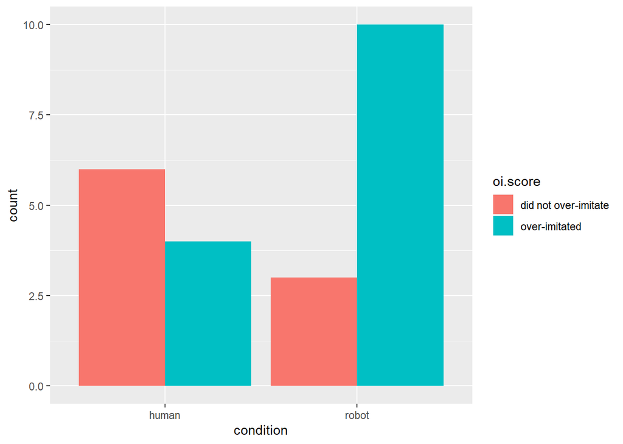

```r
nao_bar <- ggplot(nao_1, aes(x = condition, fill = oi.score)) +
  geom_bar(stat="count", position = position_dodge())
nao_bar
```

### Optional Task: A Nice Graph

The graph in Task 3 is not very good. Use the R Cookbook under Finished Examples here and Modifying the Text of Legend Titles and Labels, and Kinds of Scales here to change the labels and colours.

#### Example Nice Graph

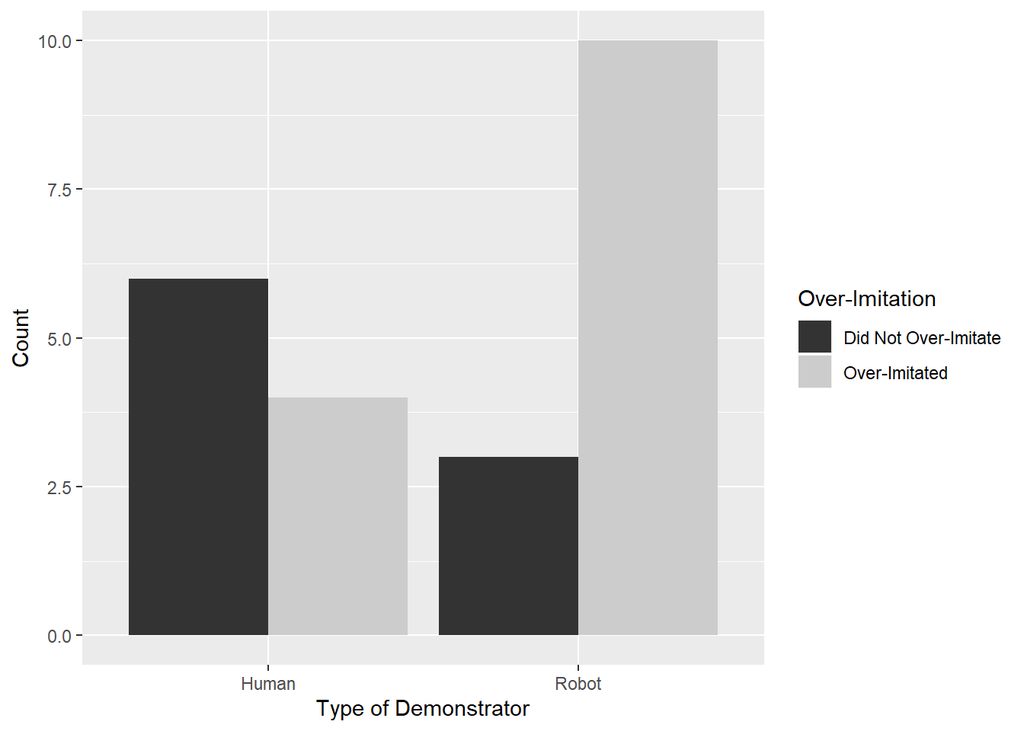

```r
nao_bar <- ggplot(nao_1, aes(x = condition, fill = oi.score)) +
  geom_bar(stat="count", position = position_dodge()) +
    ylab("Count") +
  scale_x_discrete(name = "Type of Demonstrator", labels = c("Human", "Robot")) +
  scale_fill_grey(name = "Over-Imitation", labels = c("Did Not Over-Imitate", "Over-Imitated"))
nao_bar
```